# Fitting Spatial Masks to Point Coordinate Data

# Section 5 — Concavity sweep on a crescent

A crescent is a severe test of the concave hull: it has a large, deep concavity spanning most of the shape. This sweep lets you calibrate the `concavity` parameter on a shape where the expected correct answer is obvious.

```r
theta        <- seq(0.2, pi - 0.2, length.out = 300)
coords_cres  <- data.frame(
  x = cos(theta) * (1 + rnorm(300, 0, 0.08)) * 3,
  y = sin(theta) * (1 + rnorm(300, 0, 0.08)) * 3 - cos(theta) * 1.5)

pal <- c("#e74c3c", "#e67e22", "#27ae60", "#2980b9")
sw  <- mapply(function(cv, col) {
  m <- fit_spatial_mask(coords_cres, method = "concave",
                         concavity = cv, verbose = FALSE)
  plot_mask(m, coords_cres, title = paste0("concavity = ", cv),
            fill = col, border = col)
}, c(1.2, 2, 3, 5), pal, SIMPLIFY = FALSE)
```

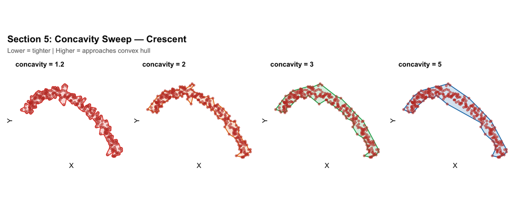

```r
wrap_plots(sw, nrow = 1) +
  plot_annotation(
    title    = "Section 5: Concavity Sweep — Crescent",
    subtitle = "Lower = tighter | Higher = approaches convex hull",
    theme    = theme(plot.title    = element_text(face = "bold", size = 13),
                     plot.subtitle = element_text(size = 9, color = "grey40")))
```

# Section 6 — Buffer and smoothing

After fitting, two post-processing options are available:

- **`buffer_dist`**: expands the mask outward by this distance in coordinate units using `sf::st_buffer()`. Useful when you want a small safety margin to ensure all cells fall inside the mask, or when points are sparse near the boundary.
- **`smooth_mask`**: applies `sf::st_simplify()` to reduce the vertex count and round jagged boundary segments. Controlled by `smooth_tolerance` (default: 1% of bounding box diagonal).

```r
r           <- sqrt(runif(250, 0.4^2, 1^2))
ang         <- runif(250, 0, 2 * pi)
coords_ring <- data.frame(x = r * cos(ang) * 5,
                           y = r * sin(ang) * 5)

m6a <- fit_spatial_mask(coords_ring, method = "concave", concavity = 2,
                         buffer_dist = 0,   smooth_mask = FALSE, verbose = FALSE)
m6b <- fit_spatial_mask(coords_ring, method = "concave", concavity = 2,
                         buffer_dist = 0.3, smooth_mask = FALSE, verbose = FALSE)
m6c <- fit_spatial_mask(coords_ring, method = "concave", concavity = 2,
                         buffer_dist = 0.3, smooth_mask = TRUE,
                         smooth_tolerance = 0.15, verbose = FALSE)
```

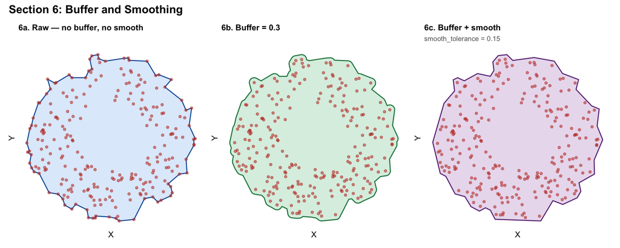

```r
plot_mask(m6a, coords_ring,
          title = "6a. Raw — no buffer, no smooth") +
plot_mask(m6b, coords_ring,
          title = "6b. Buffer = 0.3",
          fill = "#27ae60", border = "#1e8449") +
plot_mask(m6c, coords_ring,
          title = "6c. Buffer + smooth",
          subtitle = "smooth_tolerance = 0.15",
          fill = "#8e44ad", border = "#6c3483") +
plot_annotation(
  title = "Section 6: Buffer and Smoothing",
  theme = theme(plot.title = element_text(face = "bold", size = 13)))
```

**When to use each:**

- `buffer_dist`: use when downstream point-in-mask tests are failing for points you know should be inside (e.g. points right on the boundary). A value of 1–5% of the domain width is usually safe.
- `smooth_mask`: use when you want a visually clean boundary for publication figures, or when a jagged boundary is causing downstream geometric operations to be slow or numerically unstable. Be careful: large `smooth_tolerance` values can erase real tissue features.

# Section 7 — Topologically complex cases: holes and islands

The `"raster"` method is the recommended approach for masks that need to represent **holes** (vessel lumens, necrotic cores, tissue tears) or **disconnected islands**. It is also the fastest method for large point clouds (100k+ cells).

## How the raster method works

1. **Bin** all points onto a regular `raster_resolution × raster_resolution` grid.
2. **Convolve** the binary occupancy grid with a 2D isotropic Gaussian of width `raster_sigma` (in coordinate units). This is equivalent to placing a Gaussian “blob” at every point and summing — the value at each cell represents how much point density is nearby.
3. **Threshold** at `raster_threshold × max(field)`. Cells above threshold are “inside”; cells below are “outside”.
4. **Build** one axis-aligned rectangle per inside cell, then **dissolve** all rectangles with `sf::st_union()`. GEOS handles the topology automatically — holes and islands emerge from the geometry without any ring-winding logic.
5. **Smooth** the staircase boundary with a morphological close (buffer out then in by ~half the cell diagonal).

## Key tuning parameters

| Parameter | Effect |
| --- | --- |
| `raster_sigma` ↑ | Holes fill in, islands merge, boundary smooths |
| `raster_sigma` ↓ | Fine holes and gaps preserved |
| `raster_threshold` ↑ | Mask shrinks; requires denser local coverage |
| `raster_threshold` ↓ | Mask grows; accepts sparse regions |
| `raster_resolution` ↑ | Finer grid; more detail; slower union step |

> **Units note:** `raster_sigma` is in **coordinate units** (same as x and y). If your tissue coordinates span 0–10, a `raster_sigma` of 0.25 means each Gaussian blob has a standard deviation of 0.25 tissue units. `NULL` sets sigma automatically to 3% of the domain width.

## 7a — Donut: single interior void

```r
r_d          <- sqrt(runif(800, 2^2, 5^2))
th_d         <- runif(800, 0, 2 * pi)
coords_donut <- data.frame(x = r_d * cos(th_d),
                            y = r_d * sin(th_d))

m7a_r <- fit_spatial_mask(coords_donut, method = "raster",
  raster_resolution = 256L, raster_sigma = 0.25, raster_threshold = 0.2,
  verbose = FALSE)
m7a_c <- fit_spatial_mask(coords_donut, method = "convex", verbose = FALSE)
```

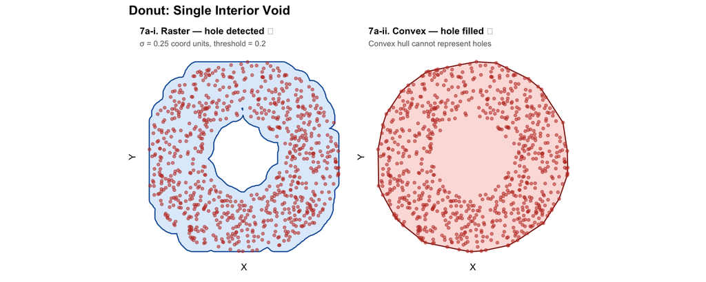

```r
plot_mask(m7a_r, coords_donut,
          title    = "7a-i. Raster — hole detected ✓",
          subtitle = "σ = 0.25 coord units, threshold = 0.2") +
plot_mask(m7a_c, coords_donut,
          title    = "7a-ii. Convex — hole filled ✗",
          subtitle = "Convex hull cannot represent holes",
          fill = "#e74c3c", border = "#922b21") +
plot_annotation(
  title = "Donut: Single Interior Void",
  theme = theme(plot.title = element_text(face = "bold", size = 13)))
```

The raster method naturally detects the empty centre as a region of low convolved density, below the threshold. The convex hull cannot ever represent a hole — it is by definition the smallest convex polygon containing all the points.

## 7b — Swiss cheese: multiple holes

```r
.circle_mat <- function(cx, cy, r, n = 100) {
  th  <- seq(0, 2 * pi, length.out = n)
  mat <- cbind(cx + r * cos(th), cy + r * sin(th))
  rbind(mat, mat[1L, ])
}

hdefs <- list(
  list(cx = 2.5, cy = 7.5, r = 1.1),
  list(cx = 7.0, cy = 6.5, r = 1.4),
  list(cx = 4.0, cy = 2.5, r = 0.9),
  list(cx = 8.0, cy = 2.0, r = 1.2)
)

sample_in_polygon <- function(poly_sf, n, max_tries = 20) {
  bb <- sf::st_bbox(poly_sf); mu <- sf::st_union(poly_sf)
  pts <- data.frame(x = numeric(0), y = numeric(0))
  for (i in seq_len(max_tries)) {
    if (nrow(pts) >= n) break
    cnd <- data.frame(x = runif(n * 8, bb["xmin"], bb["xmax"]),
                      y = runif(n * 8, bb["ymin"], bb["ymax"]))
    ok  <- as.logical(sf::st_within(
      sf::st_as_sf(cnd, coords = c("x","y")), mu, sparse = FALSE)[, 1L])
    pts <- rbind(pts, cnd[ok, ])
  }
  pts[seq_len(min(n, nrow(pts))), ]
}

outer_sq     <- sf::st_sfc(sf::st_polygon(list(
  rbind(c(0,0), c(10,0), c(10,10), c(0,10), c(0,0)))))
hcircles     <- lapply(hdefs, function(h)
  sf::st_polygon(list(.circle_mat(h$cx, h$cy, h$r))))
swiss_region <- sf::st_difference(outer_sq,
  sf::st_sfc(sf::st_union(sf::st_sfc(hcircles))))
coords_swiss <- sample_in_polygon(swiss_region, n = 1500)

m7b_r <- fit_spatial_mask(coords_swiss, method = "raster",
  raster_resolution = 256L, raster_sigma = 0.25, raster_threshold = 0.2,
  verbose = FALSE)
m7b_c <- fit_spatial_mask(coords_swiss, method = "concave",
  concavity = 1.8, verbose = FALSE)
```

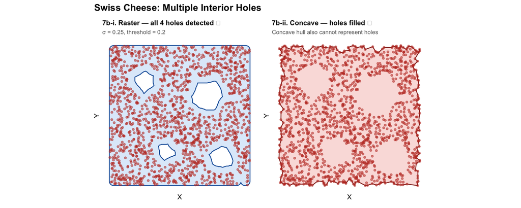

```r
plot_mask(m7b_r, coords_swiss,
          title    = "7b-i. Raster — all 4 holes detected ✓",
          subtitle = "σ = 0.25, threshold = 0.2") +
plot_mask(m7b_c, coords_swiss,
          title    = "7b-ii. Concave — holes filled ✗",
          subtitle = "Concave hull also cannot represent holes",
          fill = "#e74c3c", border = "#922b21") +
plot_annotation(
  title = "Swiss Cheese: Multiple Interior Holes",
  theme = theme(plot.title = element_text(face = "bold", size = 13)))
```